# `ghc-exactprint`: a foundation for refactoring

# Roadmap

- The **problem** we are trying to solve
- The **solution** that we have so far
- Applications of `ghc-exactprint`
- Future work extending `ghc-exactprint`

# Demo

- `apply-refact`, automatically applies hlint's suggestions
- A GSOC project

# The Problem

# Two Considerations

1. A (more) natural API for refactoring
2. GHC API - essential for more complicated operations

# Representations for Refactoring

- Choose your representation based on what kind of operations you want to support.

# The most important refactoring operation...

- The identity refactoring

```haskell
refactor :: FilePath -> IO ()
refactor = return ()
```

# But also...

- Moving expressions
- Adding parameters
- and so on...

It's important to consider them all when choosing a representation.

# The expectation

- Be able to write generic functions which operate on the AST.
- In practice, this is impossible, there is not enough information in the AST

```haskell
module Foo where

expr = subDef
  where
    subDef = case True of
               False -> True
               True -> False
```

```haskell
module Foo where

expr = case True of
         False -> True
         True -> False
```

# Solution

# Relative Source Positions

- Traditionally, ASTs have absolute source positions

```haskell
module Foo where

expr = subDef
  where
    subDef = case True of
               False -> True
               True -> False
```

- Original source spans are indexes

```haskell
module Foo where

expr = subDef
  where
    subDef = case True of
               False -> True
               True -> False
```

# Datatypes

```haskell
data AnnKey = AnnKey SrcSpan Constr

mkAnnKey :: Data a => Located a -> AnnKey
```

```haskell
type Anns = Map AnnKey Annotation
```

```haskell
data Annotation = Ann
  {
    annEntryDelta          :: !DeltaPos
  , annPriorComments       :: ![(Comment,  DeltaPos)]
  , annFollowingComments   :: ![(Comment,  DeltaPos)]
  , annsDP                 :: ![(KeywordId, DeltaPos)]


  -- Unfortunate necessities
  , annSortKey         :: !(Maybe [GHC.SrcSpan])
  , annCapturedSpan    :: !(Maybe AnnKey)
  } deriving (Typeable,Eq)
```

- Don't need to worry about these annotations.
- Any changes are *local*.
- Can move around elements freely.

# Generating this map

- Built around a free monad.
- We create a data structure which describes which keywords each AST element *could* have.

```haskell
class Data ast => Annotate ast where
  markAST :: GHC.SrcSpan -> ast -> Annotated ()
```

```haskell
data instance T Int = A
```

```haskell
instance (GHC.DataId name,GHC.OutputableBndr name,GHC.HasOccName name,Annotate name)
   => Annotate (GHC.TyFamInstDecl name) where

  markAST _ (GHC.TyFamInstDecl eqn _) = do
    mark GHC.AnnType
    mark GHC.AnnInstance
    markLocated eqn
    markTrailingSemi
```

# The two phases

Both are just different interpreters of the free monad.

1. Relativisation
- GHC dumps the keyword location information in an unhelpful format.
- Use this information and the actual source spans to create relative positions.
2. Printing - Generalised to support outputting to different formats

```haskell
semanticPrintM :: (Annotate ast, Monoid b, Monad m) =>
              -- ^ How to surround an AST fragment
              (forall a . Data a => GHC.Located a -> b -> m b)
              -> (String -> m b) -- ^ How to output a token
              -> (String -> m b) -- ^ How to output whitespace
              -> GHC.Located ast
              -> Anns
              -> m b
```

# Intelligent Syntax Highlighting

- "Smart" highlighting using `semanticPrintM`

```
foo = do
  case x of
    True -> foo
    False -> foo

baz = "Another decl"
```

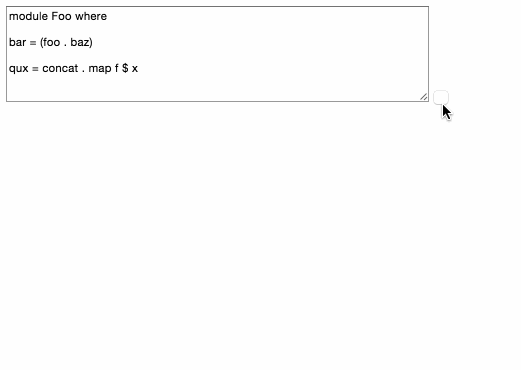

# Hackage Testing

- Tested on all files which don't user CPP
- 65 000 in total
- 40 well categorised failures which we hope to fix for GHC 8.0

# Fixing GHC

- First time the source locations had been fully tested
- Alan wrote over 40 patches fixing small parser bugs

# Difficulties

# CPP is EVIL

- Requires knowledge of the whole project (the `cabal_macros.h` file)
- Similar concerns with listing extensions in the cabal file.
- Please try to use the `*-compat` modules!

# Strange Source files

```haskell
import Data.Char
e=181021504832735228091659724090293195791121747536890433

u(f,m)x=i(m(x),       [],let(a,b)=f(x)       in(a:u(f,m)b))
(v,h)=(foldr(\x(y    )->00+128*y+x)0,u(     sp(25),((==)"")))
p::(Integer,Integer )->Integer      ->     Integer    --NotInt
p(n,m)x     =i(n==0 ,1,i(z n             ,q(n,m)x,    r(n,m)x))
i(n,e,d     )=if(n) then(e)              else  (d)    --23+3d4f
(g,main     ,s,un)= (\x->x,             y(j),\x->x*x,unlines)--)
j(o)=i(take(2)o==   "e=","e="++t        (drop(4-2)o),i(d>e,k,l)o)
l=un.map (show.p      (e,n).v.map(      fromIntegral{-g-}.ord)).h
k=co.map(map(chr       .fromIntegral    ).w.p(d,n).   read).lines
(t,y)=(\ (o:q)->              i(o=='-'  ,'1','-' ):   q,interact)
q(n,m)x=   mod(s(    p(        div(n)2, m{-jl-})x)    )m--hd&&gdb
(r,z,co)    =(\(n,   m)x->mod(x*p(n-1,  m)x)m,even    ,concat)--6
(w,sp)=(    u(\x->(   mod(x)128,div(x   )128),(==0    )),splitAt)

d=563347325936+1197371806136556985877790097-563347325936
n=351189532146914946493104395525009571831256157560461451
```

# `TransformListComp`

```haskell
foo = [ (x, y) | x <- xs,
                 y <- ys,
                 then group using permutations ]
```

- Only used in 5 packages.

# Applications

# HaRe

- Convert If expressions to Case expressions
- Renaming
- Demotion, Promotion
- Duplication

[video not shown]

# Not quite there

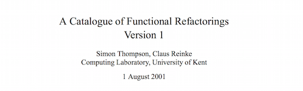

> You wouldn't believe how frustrating it has been to have put so much effort into building a real tool, for the full language, then not be able to use it because the defacto standard is so different from the official one.

[video not shown]

# `ghc-reskin`

Andrew Gibiansky's proposed `ArgumentDo` extension.

Uses a modified copy of GHC's parser and `ghc-exactprint` to write a preprocessor which rewrites source files.

```haskell
foo :: IO ()
foo = when True $ do
  return ()
```

```haskell
foo :: IO ()
foo = when True do
  return ()
```

# Monad-Fail Proposal

- Removing the fail method from the monad typeclass
- Simple, well-defined refactoring.
- A tool which library authors can use to update and review the changes.

```haskell
{-# LANGUAGE Haskell2010 #-}

module Maybe1 where

data Maybe' a = Nothing' | Just' a

instance Monad Maybe' where
    return = Just'

    Nothing' >>= _ = Nothing'
    Just' x  >>= f = f x

    fail _ = Nothing'
```

```haskell
module Maybe1 where

data Maybe' a = Nothing' | Just' a

instance Functor Maybe' where
    fmap f m    = m >>= pure . f

instance Applicative Maybe' where
    pure = Just'
    f1 <*> f2   = f1 >>= \v1 -> f2 >>= (pure . v1)

instance Monad Maybe' where
    Nothing' >>= _  = Nothing'
    Just' x  >>= f  = f x

instance MonadFail Maybe' where
    fail _ = Nothing'
```

# Questions

# Future Work

# Pattern Synonyms

- Define data constructors separately from the types they construct

```haskell
 pattern MyJust :: a -> Maybe a
 pattern (MyJust a) = Just a
```

- Keep the same interface, change the implementation
- Observation: users like writing programs with the simplified HSE AST.
- Idea: Use pattern synonyms to provide a nicer interface for the GHC AST.

# The Goal: Before

```haskell
import Language.Haskell.Exts.Annotated.Syntax

-- my complicated program ...
```

# The Goal: After

- A new module `Language.Haskell.Exts.Annotated.Syntax.Compat`

```haskell
import Language.Haskell.Exts.Annotated.Syntax.Compat

-- the same complicated program ..
```

- A current example is the `psqueues` package which has 3 implementations of a priority queue.

# Extending GHC: Making Pattern Synonyms more like data constructors

- Problem: You currently have to explicitly import and export pattern synonyms.
- Special keyword as they are in the same namespace as data constructors.

```haskell
{-# LANGUAGE PatternSynonyms #-}

module Foo(pattern P) where

data A = A

pattern P :: A
pattern P = A
```

```haskell
{-# LANGUAGE PatternSynonyms #-}
module Baz where

import Foo(pattern P)
```

- The consumer is aware they are using a pattern synonym, no good!
- Solution: Associate pattern synonyms with type constructors when *exporting*

```haskell
{-# LANGUAGE PatternSynonyms #-}

-- P is *not* a data constructor for A
module Foo(A(P)) where

data A = A

pattern P :: A
pattern P = A
```

```haskell
{-# LANGUAGE PatternSynonyms #-}

module Baz where

-- Also imports `P`.
import Foo (A(..))
```

- The user is no longer aware whether `P` is a pattern synonym or an actual constructor for `A`. Good!

# Record Pattern Synonyms

- We can define *prefix* and *infix* pattern synonyms but not *record* pattern synonyms.
- Pattern synonyms which act just like record data constructors.

```haskell
{-# LANGUAGE PatternSynonyms #-}

module Foo where

data Point = Point (Int, Int)

pattern MyPoint :: Int -> Int -> Point
pattern MyPoint {x, y} = Point (x,y)
```

```haskell
data Point = MyPoint { x :: Int, y :: Int }
```

# End Result

- A library which looks like `haskell-src-exts` but is built on the GHC parser.
- Name resolution and type checking for free.
- Only one parser to update!